# Spatial Predicate Relationships

Examples of common spatial relationships using the R *sf* package

Geometry

Relationship

Definition

Intersects

Disjoint

Touches

Overlaps

Within

Contains

Crosses

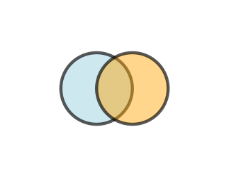

Overlapping circles

The two polygons partially share the same area, but neither completely contains the other.

✓

✕

✕

✓

✕

✕

✕

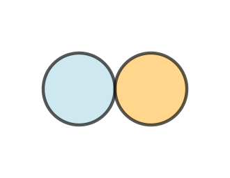

Touching circles

The polygon boundaries meet, but their interiors do not overlap.

✓

✕

✓

✕

✕

✕

✕

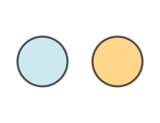

Disjoint circles

The two polygons have no points in common.

✕

✓

✕

✕

✕

✕

✕

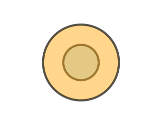

A within B

Geometry A lies completely inside geometry B.

✓

✕

✕

✕

✓

✕

✕

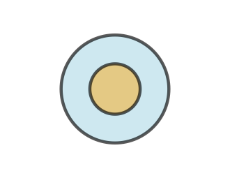

A contains B

Geometry A completely contains geometry B.

✓

✕

✕

✕

✕

✓

✕

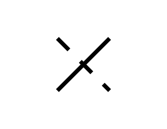

Crossing lines

The two lines pass through each other at an interior point.

✓

✕

✕

✕

✕

✕

✓

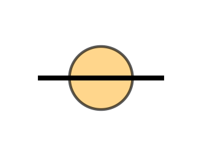

Line crossing circle

The line enters and exits the polygon, passing through its interior.

✓

✕

✕

✕

✕

✕

✓

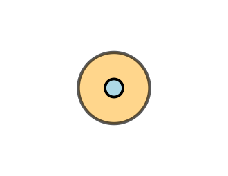

Point within circle

The point lies inside the interior of the polygon.

✓

✕

✕

✕

✓

✕

✕

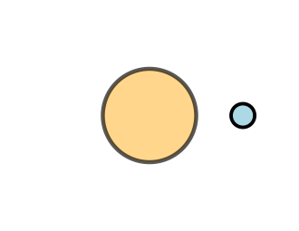

Point outside circle

The point lies outside the polygon and shares no point with it.

✕

✓

✕

✕

✕

✕

✕

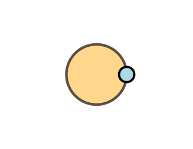

Point on circle boundary

The point lies on the boundary of the polygon but not in its interior.

✓

✕

✓

✕

✕

✕

✕

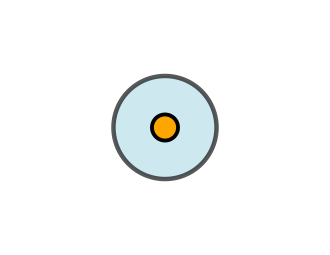

Circle contains point

The polygon contains the point in its interior.

✓

✕

✕

✕

✕

✓

✕

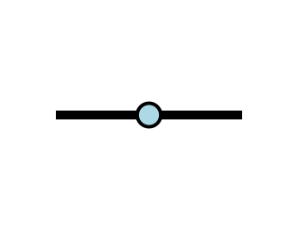

Point on line interior

The point lies on the interior of the line.

✓

✕

✕

✕

✓

✕

✕

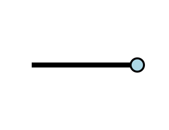

Point touching line endpoint

The point coincides with an endpoint, which forms part of the line boundary.

✓

✕

✓

✕

✕

✕

✕

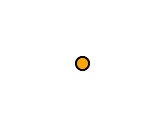

Coincident points

The two points occupy exactly the same location.

✓

✕

✕

✕

✓

✓

✕

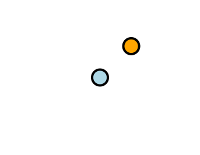

Separated points

The two points occupy different locations.

✕

✓

✕

✕

✕

✕

✕